# Normal Distributions

Bret Larget

This R Markdown document includes contributions from Professor Jessi Kehe

### Setup details

- You will need the package **tidyverse** for this file
- This lecture use the following scripts, assumed to be in your course scripts directory.
  - `COURSE/scripts/viridis.R`
  - `COURSE/scripts/ggprob.R`
- The file `ggprob.R` contains a number of functions for graphing probability distributions in a tidyverse-friendly manner.

## Overview

- Normal distributions are continuous distributions
- All normal distributions have the same overall shape: symmetric, unimodal, bell-shaped
- The shape of the normal density curve is completely determined by its mean ($\mu$) and its standard deviation ($\sigma$):
- The density function has the following formula

$$f(x) = \frac{1}{\sigma\sqrt{2\pi}} e^{-\frac{1}{2}\left(\frac{x-\mu}{\sigma}\right)^2}$$

- The mean $\mu$ is located at the center and the standard deviation $\sigma$ controls the spread.

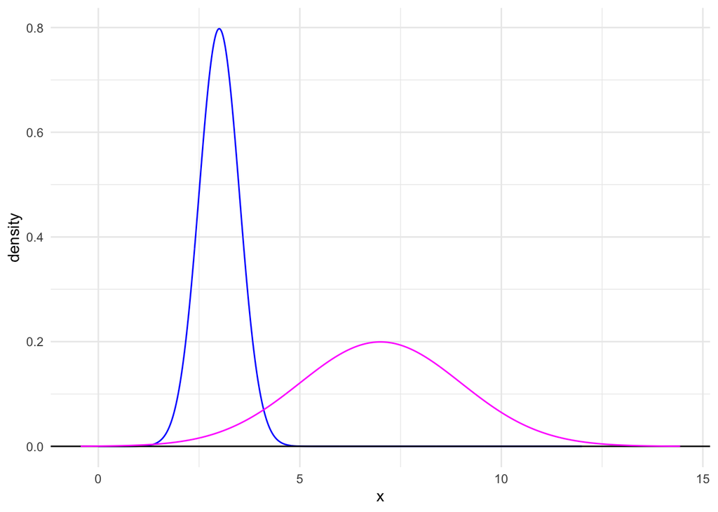

```r
mu = 3
sigma = 0.5
mu2 = 7
sigma2 = 2

gnorm(mu=mu, sigma=sigma, a=-0, b=12, color="blue",
      fill=NULL, title=FALSE) +
  geom_norm_density(mu = mu2, sigma = sigma2, color = "magenta") +
  theme_minimal()
```

## Normal Probabilities

- Suppose that $X \sim \text{N}(\mu, \sigma)$
  - this means the random variable $X$ follows a normal distribution with mean $\mu$ and standard deviation $\sigma$.
- We can calculate probabilities for a Normal distribution using R:

$$P(a \leq X \leq b)$$

- This is the area under the density curve between $b$ and $a$
- The function `pnorm()` calculates areas under normal curves.
- The arguments in order are:
  - `q`: a location on the x axis
  - `mean`: the mean of the distribution, or $\mu$, default value is 0
  - `sd`: the standard deviation of the distribution, or $\sigma$, default value is 1
  - `lower.tail`: logical to calculate area to the left, default value is `TRUE`
  - `log.p`: logical to calculate log of the probability, default value is `FALSE`.

### Examples:

- Find $\mathsf{P}(X < 80)$

```r
## naming arguments; I usually do not
pnorm(q=80, mean=100, sd=25)
```

```
## [1] 0.2118554
```

```r
## without the names
pnorm(80, 100, 25)
```

```
## [1] 0.2118554
```

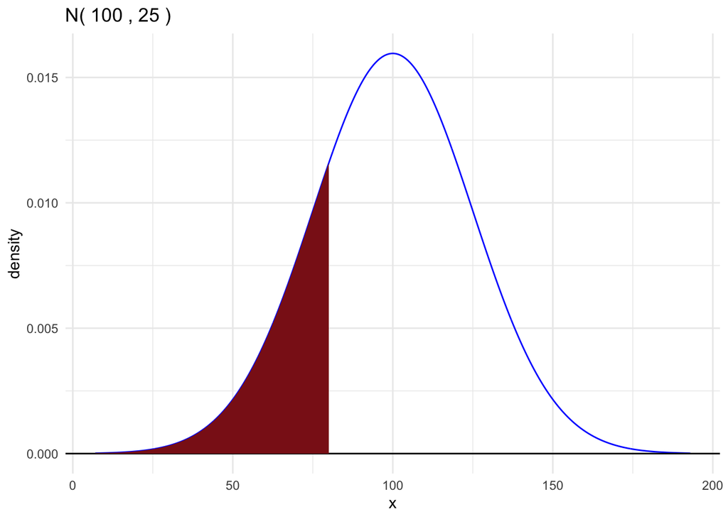

```r
## gnorm is defined in ggprob.R
## you need to call source("../../scripts/ggprob.R") in set-up for this to work
## a is the left endpoint of the interval to fill
## b is the right endpoint of the interval to fill
## use NULL for the default value (all the way to the left or right)
gnorm(mu = 100, sigma = 25) +
  geom_norm_fill(mu = 100, sigma=25, a = NULL, b = 80) +
  theme_minimal()
```

#### Area to the right

- Find $\mathsf{P}(X > 90)$

```r
## using lower.tail
pnorm(90, 100, 25, lower.tail = FALSE)
```

```
## [1] 0.6554217
```

```r
## using subtraction
1 - pnorm(90, 100, 25)
```

```
## [1] 0.6554217
```

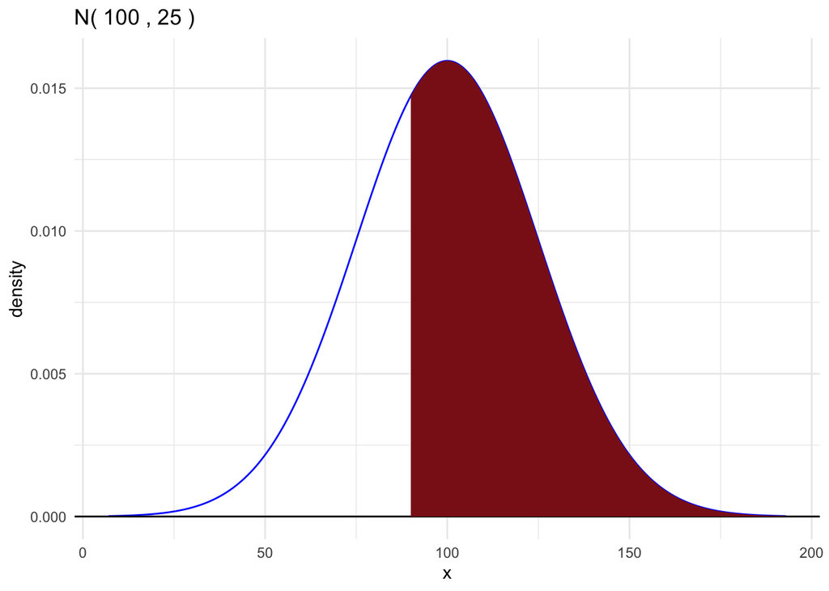

```r
## first argumment is mu, second is sigma if you do not want to specify names
## Need to repeat mu and sigma in each level: not set in aes()
gnorm(100, 25) +
  geom_norm_fill(100, 25, a = 90, b = NULL) +
  theme_minimal()
```

#### Area between two values

- Find $\mathsf{P}(50 < X < 120)$
  - Note: $\mathsf{P}(50 < X < 120) = \mathsf{P}(X < 120) - \mathsf{P}(X < 50)$

```r
## use subtraction
pnorm(120, 100, 25) - pnorm(50, 100, 25)
```

```
## [1] 0.7653945
```

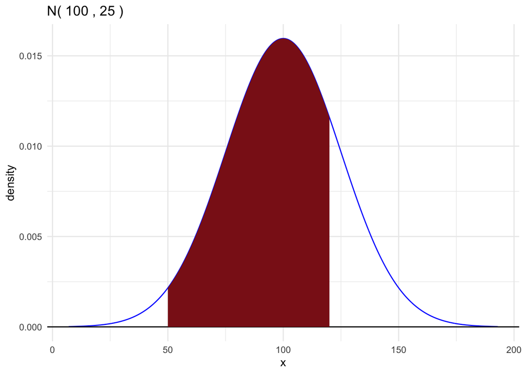

```r
gnorm(100, 25) +
  geom_norm_fill(100, 25, a = 50, b = 120) +
  theme_minimal()
```

#### Two tail areas

- Find $\mathsf{P}(|X-100| > 30)$
  - This is $\mathsf{P}(X < 70) + \mathsf{P}(X > 130)$

```r
## using lower.tail
pnorm(70, 100, 25) + pnorm(130, 100, 25, lower.tail = FALSE)
```

```
## [1] 0.2301393
```

```r
## using subtraction
pnorm(70, 100, 25) + (1 - pnorm(130, 100, 25))
```

```
## [1] 0.2301393
```

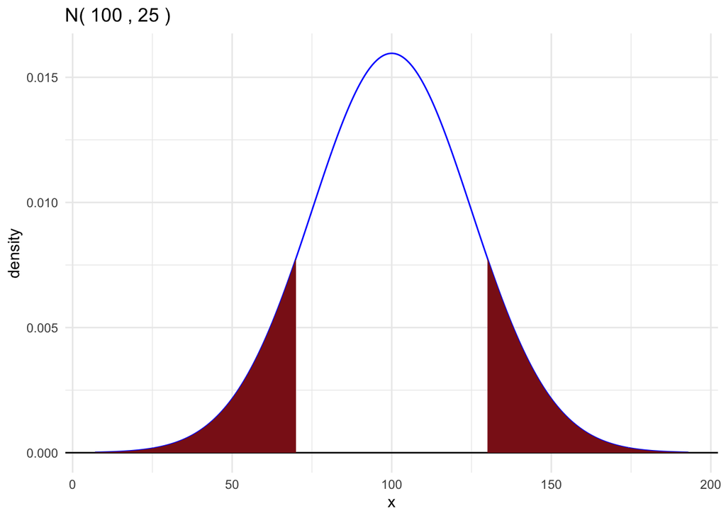

```r
gnorm(100, 25) +
  geom_norm_fill(100, 25, a = NULL, b = 70) +
  geom_norm_fill(100, 25, a = 130, b = NULL) +
  theme_minimal()
```

## Standard Normal Distribution and Standardization

- A *standard normal distribution* is a normal distribution with mean = 0 and standard deviation = 1

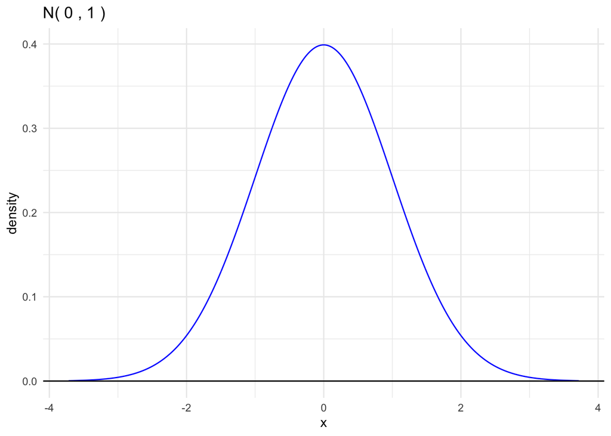

```r
gnorm() +
  theme_minimal()
```

- If $X \sim \text{N}(\mu, \sigma)$, then $Z = \left(\frac{X-\mu}{\sigma}\right) \sim \text{N}(0, 1)$
- An implication is $\mathsf{P}(X < a) = \mathsf{P}\left( Z < \frac{a-\mu}{\sigma}\right)$

#### Example

$X \sim \text{N}(100, 25)$

- Find $\mathsf{P}(X < 80)$

```r
mu = 100
sigma = 25
x = 80
z = (x-mu)/25

## Using X directly
pnorm(x, mu, sigma)
```

```
## [1] 0.2118554
```

```r
## Standardizing first
## default values for the mean and sd are 0 and 1
pnorm(z)
```

```
## [1] 0.2118554
```

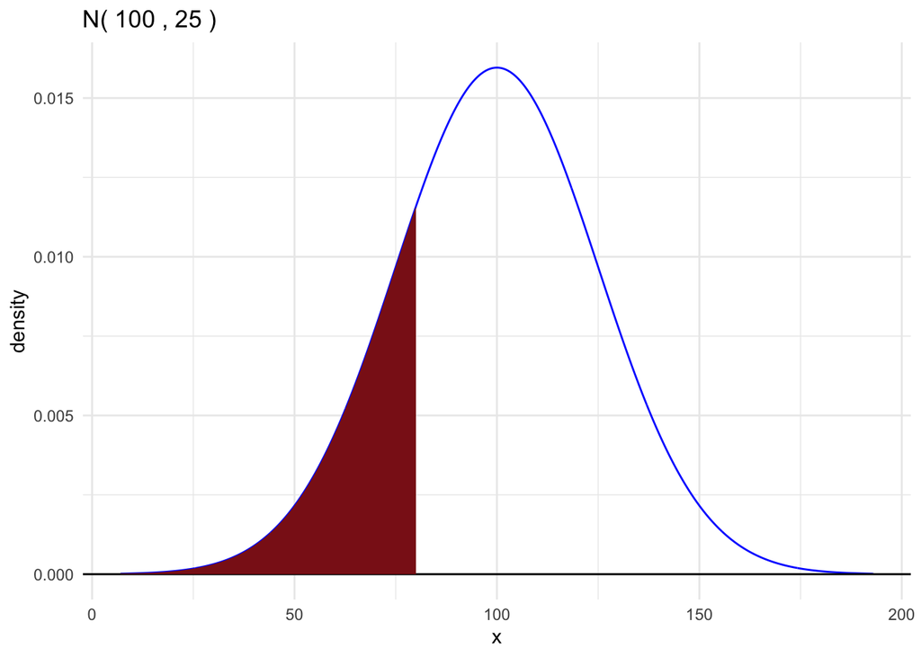

```r
gnorm(mu, sigma) +
  geom_norm_fill(mu, sigma, b=x) +
  theme_minimal()
```

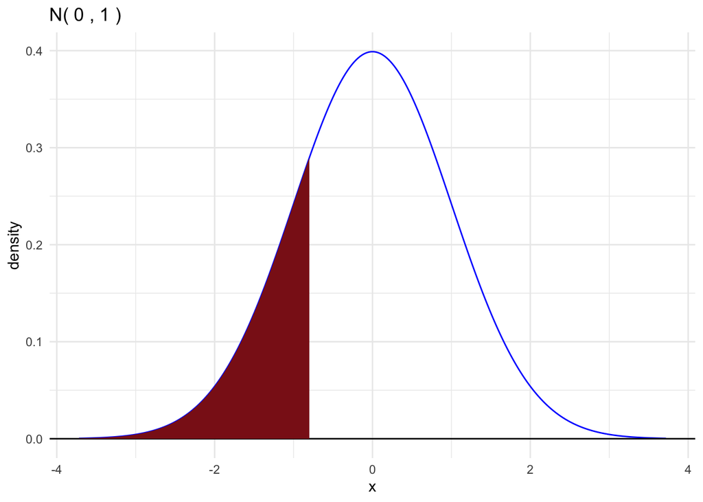

```r
gnorm() +
  geom_norm_fill(b=z) +
  theme_minimal()
```

- Notice the graphs are identical except for axis labels
- All normal curves have exactly the same shape, but they may differ in center and scale

## Normal Quantiles

- The p-quantile is the location `q` where the area to the left of `q` under the normal density is equal to `p`.
- The R function `qnorm()` makes these calculations.
- Arguments in order are:
  - `p`: the probability of the quantile
  - `mean`: mean of the distribution, $\mu$, default is 0
  - `sd`: standard deviation of the distribution, $\sigma$, default is 1
  - `lower.tail`: default is `TRUE`, if `FALSE` find locations for areas to the right
    - I **never** use this.
  - `log.p`: default is `FALSE`, if true, it returns natural log of the quantile

### Examples

$X \sim \text{N}(100, 25)$

Find the 0.1, 0.25, 0.9, 0.95, 0.975, and 0.99 quantiles of the distribution.

```r
p = c(0.1, 0.25, 0.9, 0.95, 0.975, 0.99)
mu = 100
sigma = 25

qnorm(p, mu, sigma)
```

```
## [1]  67.96121  83.13776 132.03879 141.12134 148.99910 158.15870
```

### Graphs

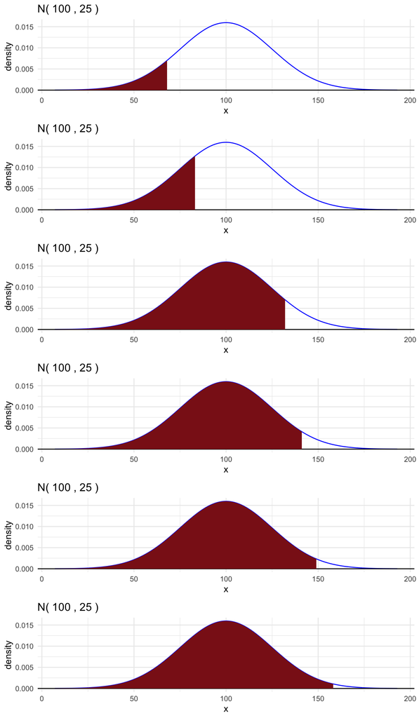

```r
## use ggarrange() to display multiple plots and map() to create a list of plots

normal_plots = p %>%
  map(~{
    gnorm(mu, sigma) +
    geom_norm_fill(mu, sigma, a = NULL, b = qnorm(.x, mu, sigma)) +
    theme_minimal()
  })

ggarrange(plots = normal_plots,
          nrow = length(p),
          ncol = 1)
```

### Simple Normal Calculation example

> The weights of packets of cookies produced by a certain manufacturer have a normal distribution with a mean of 202 g and a standard deviation of 3 g. What is the weight that should be labeled on the packet so that only 1% of the packets are underweight?
- $X \sim \text{N}(202, 3)$, want $P(X < a) = 0.01$

```r
## This gives the 1st percentile of a N(202, 3) distribution
qnorm(0.01, mean=202, sd=3, lower.tail=TRUE)
```

```
## [1] 195.021
```

```r
## Check
pnorm(195.021, mean=202, sd=3) # P(X <= 195.021) = .01
```

```
## [1] 0.01000039
```

## Normal approximation to the binomial distribution

- If $n$ is large enough, and $p$ is not too close to 0 or 1, the binomial distribution can be approximated by the normal distribution
- A rule of thumb for “large enough” is if $np(1-p) \ge 10$.
  - Under the assumptions above, if $X \sim \text{Binomial}(n,p)$, then $X \stackrel{\text{approx}}{\sim}\text{N}(np, \sqrt{np(1-p)})$
- Here is an example where the assumption is satisfied.
  - $n = 100$
  - $p = 0.5$
  - $np(1-p) = 25$

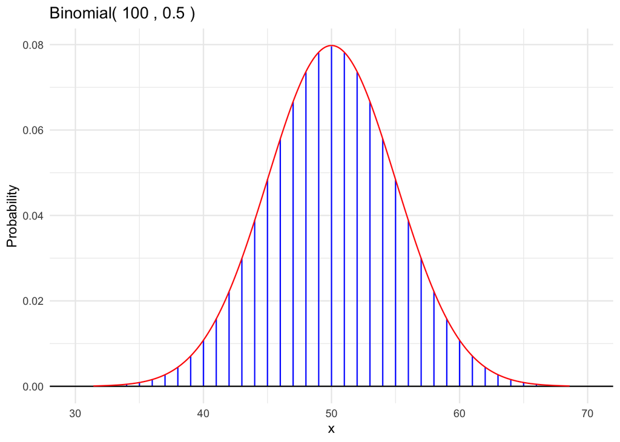

```r
## Assumptions satisfied
n = 100
p = 0.5
mu = n*p
sigma = sqrt(n*p*(1-p))

gbinom(n, p, scale=TRUE) +
  geom_norm_density(mu, sigma, color = "red") +
  theme_minimal()
```

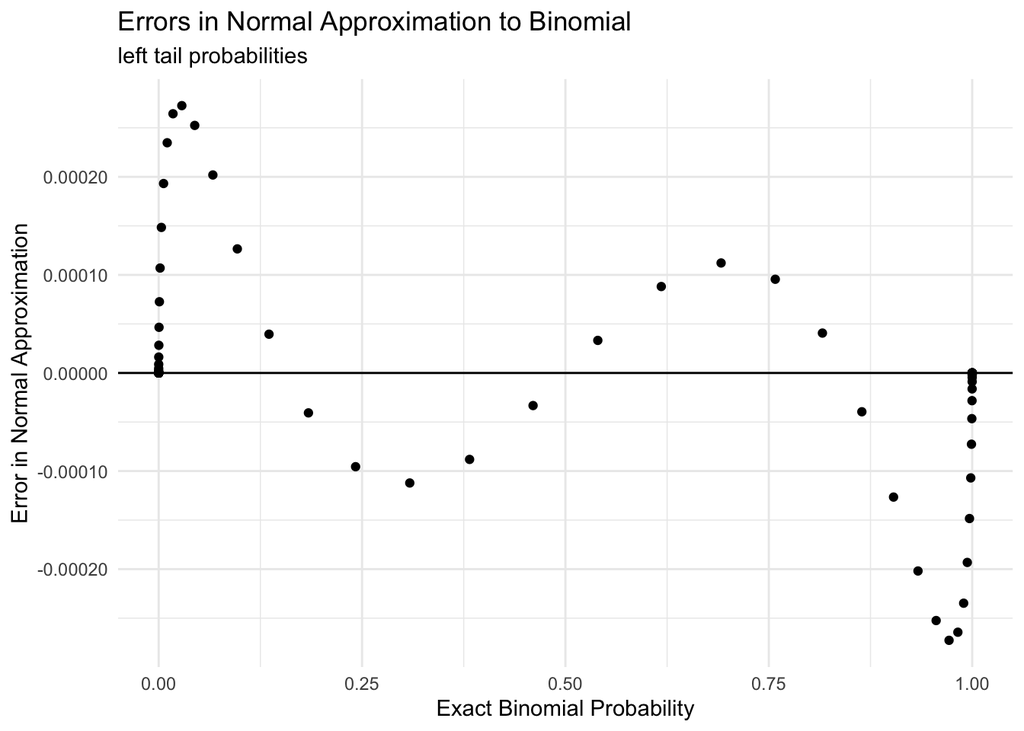

```r
### check the accuracy of normal approximation
df = tibble(k = 0:n,
            binomial_tail = pbinom(k, n, p),
            binomial_prob = dbinom(k, n, p),
            normal_tail = pnorm(k+0.5, mu, sigma),
            normal_prob = pnorm(k+0.5, mu, sigma) - pnorm(k-0.5, mu, sigma))

## Accuracy of left probabilities
ggplot(df, aes(x = binomial_tail, y = normal_tail - binomial_tail)) +
  geom_point() +
  geom_hline(yintercept = 0) +
  scale_y_continuous(label = scales::comma) +
  xlab("Exact Binomial Probability") +
  ylab("Error in Normal Approximation") +
  ggtitle("Errors in Normal Approximation to Binomial",
          subtitle = "left tail probabilities") +
  theme_minimal()
```

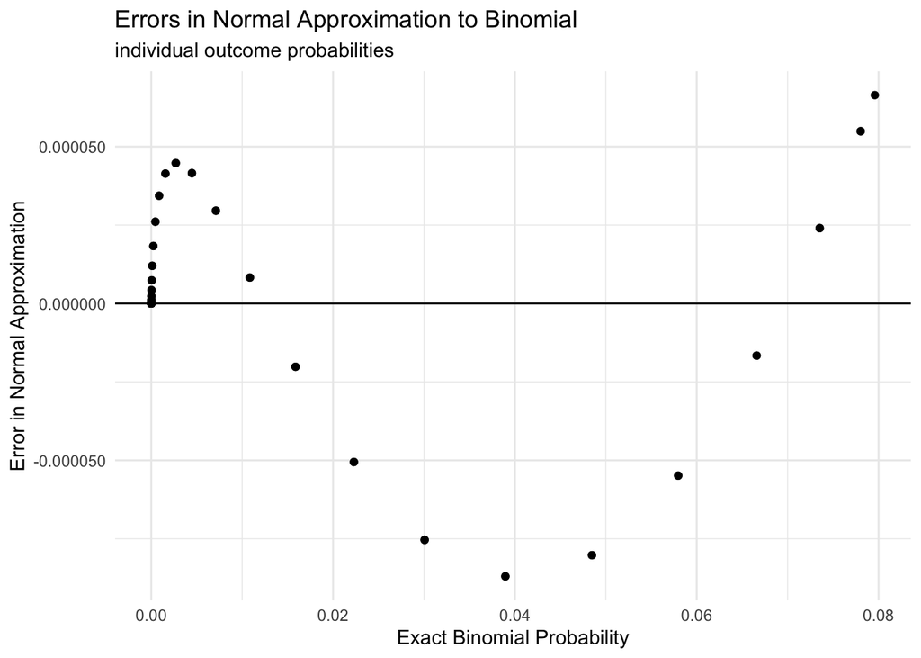

```r
## Accuracy of individual probabilities
ggplot(df, aes(x = binomial_prob, y = normal_prob - binomial_prob)) +
  geom_point() +
  geom_hline(yintercept = 0) +
  scale_y_continuous(label = scales::comma) +
  xlab("Exact Binomial Probability") +
  ylab("Error in Normal Approximation") +
  ggtitle("Errors in Normal Approximation to Binomial",
          subtitle = "individual outcome probabilities") +
  theme_minimal()
```

### Example where the approximation is poor

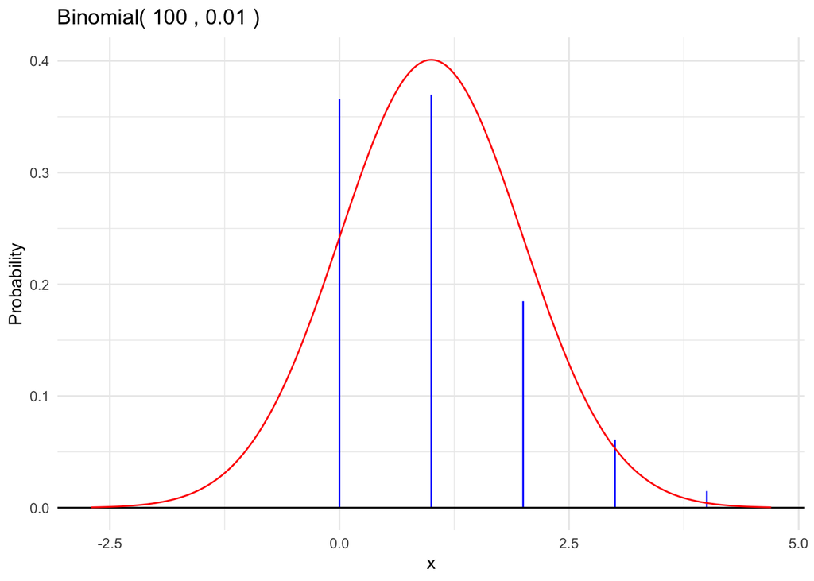

```r
## Criteria not satisfied
n = 100
p = 0.01
mu = n*p
sigma = sqrt(n*p*(1-p))

gbinom(n, p, scale=TRUE) +
  geom_norm_density(mu, sigma, color = "red") +
  theme_minimal()
```

- Error analysis

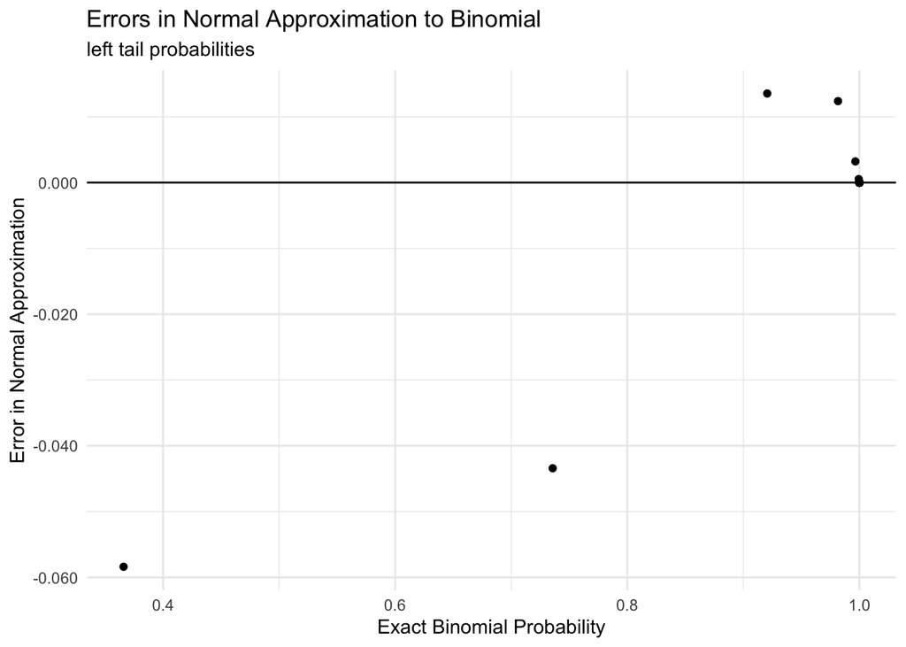

```r
### check the accuracy of normal approximation
df = tibble(k = 0:n,
            binomial_tail = pbinom(k, n, p),
            binomial_prob = dbinom(k, n, p),
            normal_tail = pnorm(k+0.5, mu, sigma),
            normal_prob = pnorm(k+0.5, mu, sigma) - pnorm(k-0.5, mu, sigma))

## Accuracy of left probabilities
ggplot(df, aes(x = binomial_tail, y = normal_tail - binomial_tail)) +
  geom_point() +
  geom_hline(yintercept = 0) +
  scale_y_continuous(label = scales::comma) +
  xlab("Exact Binomial Probability") +
  ylab("Error in Normal Approximation") +
  ggtitle("Errors in Normal Approximation to Binomial",
          subtitle = "left tail probabilities") +
  theme_minimal()
```

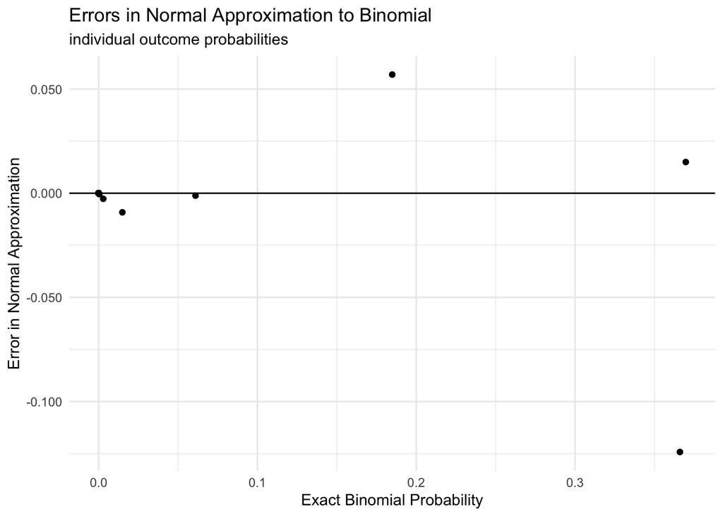

```r
## Accuracy of individual probabilities
ggplot(df, aes(x = binomial_prob, y = normal_prob - binomial_prob)) +
  geom_point() +
  geom_hline(yintercept = 0) +
  scale_y_continuous(label = scales::comma) +
  xlab("Exact Binomial Probability") +
  ylab("Error in Normal Approximation") +
  ggtitle("Errors in Normal Approximation to Binomial",
          subtitle = "individual outcome probabilities") +
  theme_minimal()
```